# TEMPEST Sapflow Initial Analysis

Radha Srinivasan

2024-08-02

## Background

This is a summary of the pipeline I have used over the past summer to analyze TEMPEST sap flow data.

### Sap Flux Density Calculations

This code currently calculates and graphs whole-tree sap flux density from January 1, 2021 - May 2, 2024.

Raw sap flow measurements are recorded in terms of difference in voltage (mV) between the two probes; due to the nature of the equations used (Granier 1985) voltage difference can be thought of as interchangeable with temperature difference.

#### Notes on vernacular:

Sap flow velocity (F) is used to describe the point/unscaled sap flow measurement, and sap flux density (Fd) would describe sap flow over a certain area (in this case, sapwood area of the tree).

## Data Wrangling

Load in our packages:

```r
library(tidyr)
library(dplyr)
library(ggplot2)
library(lubridate)
library(stringr)
library(ggpmisc)
```

Load in our data:

1. TEMPEST site data: Sapflow (mV) at 2.5 cm , soil volumetric water content($m^3 / m^3$) at 15 cm
2. GCReW site data: Photosynthetically active radiation ($\mu mol/m^2 \cdot s$), air temperature (C)
3. Species ID, DBH (cm)

```r
tmp_full <- readRDS("tmp_full.rds")
gcw_full <- readRDS("gcw_full.rds")
species <- readRDS("dbh.rds")
```

Specify pre and post TEMPEST flood weeks (including 2 weeks in June 2021):

```r
weeks_start <- c("2022-06-15", "2022-06-23", "2023-05-30", "2023-06-08", "2021-06-06", "2021-06-13")
weeks_end <- c("2022-06-21", "2022-06-29", "2023-06-05", "2023-06-14", "2021-06-12", "2021-06-19")
weeks_start<- as_date(weeks_start)
weeks_end<- as_date(weeks_end)
```

Tidy up data- match variable names between dataframes, remove outliers (sapflow voltage differences should be between 0.01 and 0.7).

```r
tmp_full %>%
  mutate(Plot = substr(Plot,1,1),
         Plot = case_when(Plot == "C" ~ "Control",
                          Plot == "F" ~ "Freshwater",
                          Plot == "S" ~ "Saltwater", )) -> tmp_full
species %>%
  mutate(Species = substr(spp,1,4),
         Species = case_when(spp == "ACRU" ~ "Red Maple",
                             spp == "LITU" ~ "Tulip Poplar",
                             spp == "FAGR" ~ "Beech")) %>%
  select(Plot, Sapflux_ID, Species) %>%
  filter(!grepl("D", Sapflux_ID)) -> species

sapflow <- tmp_full %>%
  filter(Instrument == "Sapflow",
         Value >= 0.01, Value <=0.7) %>%
  select(Plot, TIMESTAMP, Sensor_ID, Value) %>%
  mutate(sapflow_2.5cm = Value) %>%
  mutate(Date = date(TIMESTAMP))
```

Match species name with sapflow measurements and ID, create new dataframe with select variables:

```r
sapflow_sp <-
  merge(species, sapflow, by.x = c("Sapflux_ID", "Plot"), by.y = c("Sensor_ID", "Plot"), all.x = TRUE, all.y = TRUE)

mutate(sapflow_sp, ID = Sapflux_ID) -> sapflow_sp
```

## dTmax Calculations

Calculate dTmax (the maximum difference in voltage, i.e. the minimum sapflow) over a 24 hour period. Note: This value was initially calculated between the hours of midnight and 5 am, but this failed to account for instances of low sapflow during the day, so the whole 24 hour period was used.

```r
sapflow_sp %>%
  mutate(Date = date(TIMESTAMP)) %>%
  group_by(Date, Plot, Species, ID) %>%
  summarise(dTmax = max(Value, na.rm = TRUE),
            dTmax_time = TIMESTAMP[which.max(Value)])-> sapflow_dtmax
```

## F_d Calculations

Convert voltage difference to sap flux density ($F_d$,$m^3/m^2 \cdot s$ i.e. m/s) using Granier 1985 equation.

$$F = \alpha K^{b}$$
Constants alpha ($m^3/s^3$) and b were experimentally determined by Granier and depend on the power of the heat probe (0.2 W).

Implement in dataframe:

```r
sapflow_sp %>%
  left_join(sapflow_dtmax, by = c("Plot", "Species", "ID", "Date")) %>%
  mutate(F = ((0.00011899 * (((dTmax / Value) - 1)))^1.231))  -> sfd_data
```

## Allometric Equations

Scale our Fd values to be representative of the whole tree using area of sapwood (active sap-conducting xylem) based on Lu 2004 equation.

First, estimate sapwood area for each tree using species-specific allometric equations from Brantley 2016. Equations follow the format y = a* D^b, with experimentally determined coefficients for each species. Note: Brantley did not include coefficients specific to American Beech, so a general equation for diffuse-porous trees is used.

```r
inventory <- readRDS("dbh.rds")
inventory %>%
  select(Tree_ID, Sapflux_ID, spp, DBH_2024, DBH_2022, DBH_2023, DBH_2021) -> dbh

#Using allometric equations, scale Fd measurements
#DBH measurements are in cm; scale to m to match Fd units

SA <- function(Species, DBH) {
  case_when(
    Species == "Red Maple" ~ (0.5973*(DBH/100)^2.0743),
    Species == "Tulip Poplar" ~ (0.8086*(DBH/100)^1.8331),
    Species == "Beech" ~ (0.8198*(DBH/100)^1.8635))
}

dbh %>%
  mutate(Species = spp) %>%
  mutate(Species = substr(Species,1,4),
         Species = case_when(Species == "ACRU" ~ "Red Maple",
                             Species == "LITU" ~ "Tulip Poplar",
                             Species == "FAGR" ~ "Beech")) %>%
  mutate(across(starts_with("DBH_"), ~SA(Species, .), .names = "SA_{str_extract(.col, '[0-9]{4}')}")) -> sa

sa %>%
  pivot_longer(cols = starts_with("SA_"),
               names_to = "Year",
               names_prefix = "SA_",
               values_to = "SA") %>%
  mutate(Year = as.numeric(Year)) -> sa_long
```

Use sapwood areas to scale F to whole tree using Lu 2004 equation:
$$F_d = F * A_s$$

```r
mutate(sfd_data, Year = year(TIMESTAMP)) -> sfd_data

scaled <- merge(sfd_data, sa_long, by.x = c("ID", "Year", "Species"),
                by.y = c("Sapflux_ID", "Year", "Species"), all.x = TRUE)

scaled %>%
  select(ID, Year, Species, Plot, TIMESTAMP, F, SA) %>%
  mutate(Fd = SA * F) -> sf_scaled
```

Now that we have sap flux density for 2021- 2024, we want to determine the period of maximum daily sap flow and conduct our analysis only within that timeframe. Find hourly period of maximum Fd:

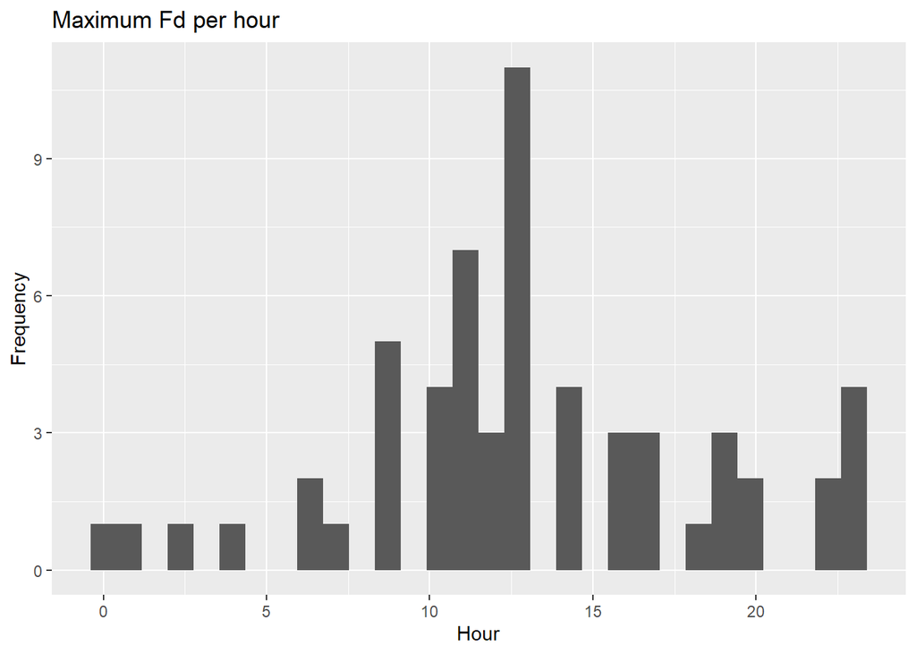

```r
sf_scaled %>%
  group_by(Plot, Species, ID) %>%
  summarise(Fdmax = max(Fd, na.rm = TRUE),
            Fdmax_time = TIMESTAMP[which.max(Fd)]) -> maxFd_time

ggplot(maxFd_time, aes(x = hour(Fdmax_time))) +
  geom_histogram() +
  labs(x = "Hour", y = "Frequency", title = "Maximum Fd per hour")
```

Peak hours seem to be between 11 AM and 12 PM. Let’s double check if it varies seasonally:

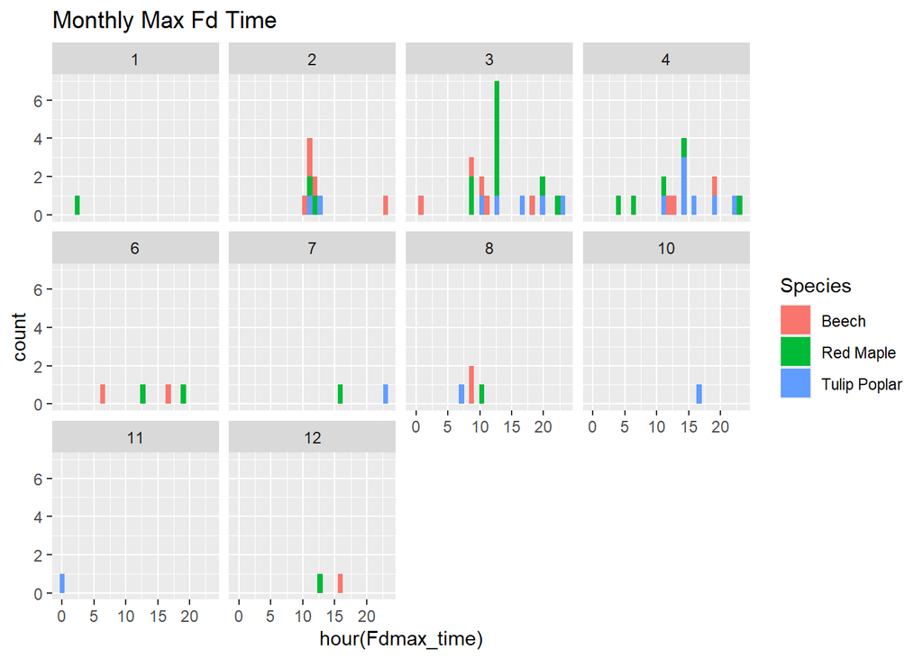

```r
ggplot(maxFd_time, aes(x = hour(Fdmax_time), fill = Species)) +
  geom_histogram() + ggtitle("Monthly Max Fd Time")+
  facet_wrap(.~month(Fdmax_time))
```

Not much seasonal variation.

Graph whole tree flux for 11-12 AM over all of 2021-2024, averaged by plot and species. These are averaged values for every 15 minutes from 11-12 AM.

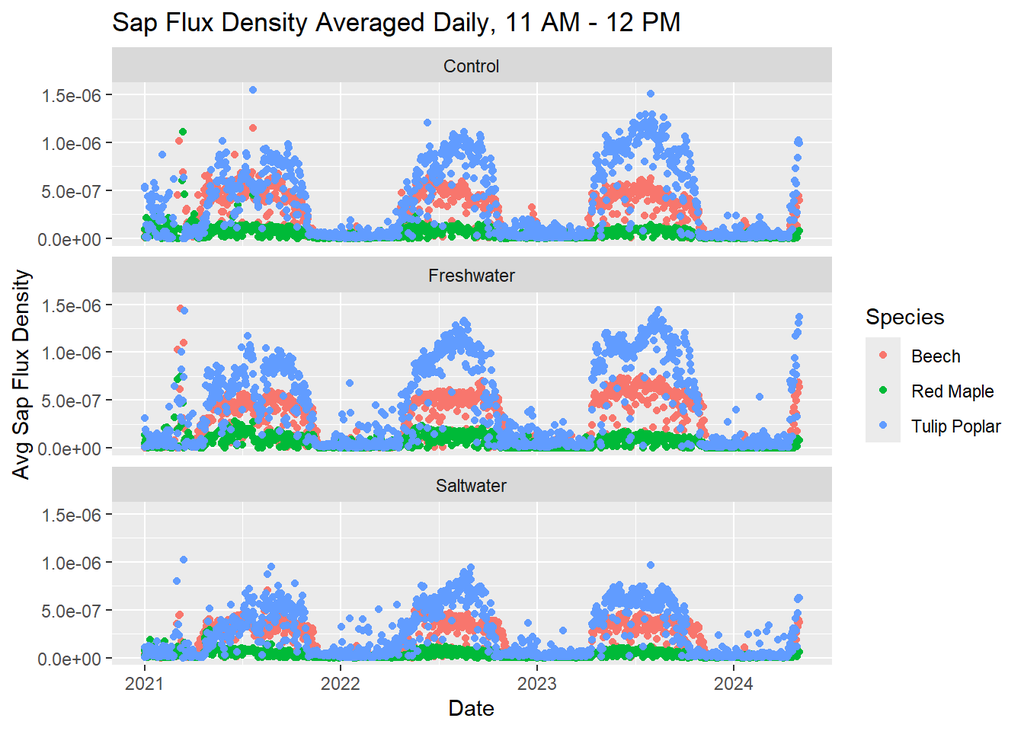

```r
sf_scaled %>%
  mutate(Hour = hour(TIMESTAMP)) %>%
  mutate(Date = date(TIMESTAMP)) %>%
  mutate(monthyr = floor_date(TIMESTAMP, unit = "week")) %>%
  filter(Hour >= 11, Hour <= 12) %>%
  filter(Fd <= 2e-06, Fd >= 0) %>%
  group_by(Plot, Species, Date) %>%
  summarise(F_avg = mean(Fd, na.rm = TRUE)) -> sf_plot_avg

ggplot(sf_plot_avg) +
  geom_point(aes (x = Date, y = F_avg, color = Species)) +
  #geom_errorbar(aes(ymin = F_avg - F_error, ymax = F_avg + F_error,
                    #x = Month, color = Species)) +
  facet_wrap(~Plot, ncol = 1, scales = "fixed") +
  labs(y = "Avg Sap Flux Density", x = "Date", title = "Sap Flux Density Averaged Daily, 11 AM - 12 PM")
```

ANOVA test to determine if difference in Fd of different treatments and species are statistically significant and a summarizing box plot (We can assume species and plot are correlated with each other, as different species likely vary under different treatments):

```r
sf_scaled %>%
  mutate(Hour = hour(TIMESTAMP)) %>%
  mutate(Date = date(TIMESTAMP)) %>%
  filter(Hour >= 11, Hour <= 12) %>%
  filter(Date >= weeks_start & Date <= weeks_end) %>%
  filter(year(TIMESTAMP) != 2021,
         F <= 0.000002, F > 0) -> anova

full_aov <- aov(F ~ Species * Plot, data = anova )

summary(full_aov)
```

```
##               Df    Sum Sq   Mean Sq F value   Pr(>F)
## Species        2 1.753e-11 8.763e-12  26.754 6.71e-12 ***
## Plot           2 1.990e-12 9.960e-13   3.040  0.04850 *
## Species:Plot   4 4.700e-12 1.175e-12   3.586  0.00665 **
## Residuals    662 2.168e-10 3.280e-13
## ---
## Signif. codes:  0 '***' 0.001 '**' 0.01 '*' 0.05 '.' 0.1 ' ' 1
```

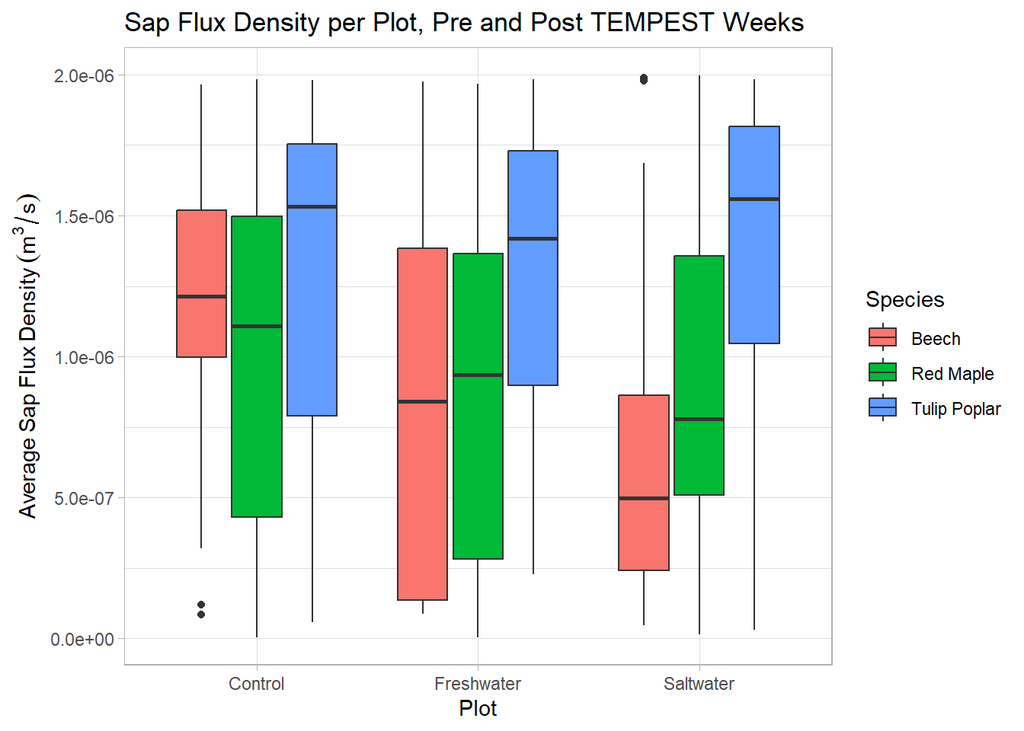

```r
ggplot(anova) +
  geom_boxplot(aes (x = Plot, y = F, fill = Species)) +
  labs(x = "Plot",
       y = expression(Average~Sap~Flux~Density~(m^3/s)),
       title = "Sap Flux Density per Plot, Pre and Post TEMPEST Weeks") +
 theme_light()
```

## Abiotic Factors

Merge our sap flow dataframe with our abiotic data:

```r
swc_15 <- tmp_full %>%
    filter(research_name == "soil_vwc_15cm") %>%
    group_by(TIMESTAMP, Plot) %>%
    drop_na(Value) %>%
    summarize(soil_vwc_15cm = mean(Value))
tmp_data <-
  left_join(sf_scaled, swc_15, by = c("Plot", "TIMESTAMP"))


gcw_full %>%
  mutate(Plot = substr(Plot,1,2),
         Plot = case_when(Plot == "W" ~ "Freshwater",)) %>%
  select(Plot, TIMESTAMP, Value, research_name) %>%
  filter(research_name != "wx_vappress15") -> gcw

gcw %>%
  filter(research_name == "wx_par_den15") %>%
  mutate(PAR = Value) %>%
  select(TIMESTAMP, PAR) -> par

gcw %>%
  filter(research_name == "wx_tempavg15") %>%
  mutate(TEMP = Value) %>%
  select(TIMESTAMP, TEMP) -> temp

full_data <-
  merge(tmp_data, par, by.x = c("TIMESTAMP"),
        by.y = c("TIMESTAMP"), all = TRUE)

full_data <-
  merge(full_data, temp, by.x = c("TIMESTAMP"),
        by.y = c("TIMESTAMP"), all.x = TRUE)
```

Lastly, we can check for linear correlations betweeen sap flow and abiotic factors. Note: Data is not available for air temperature and PAR until March 2022.

Air temperature

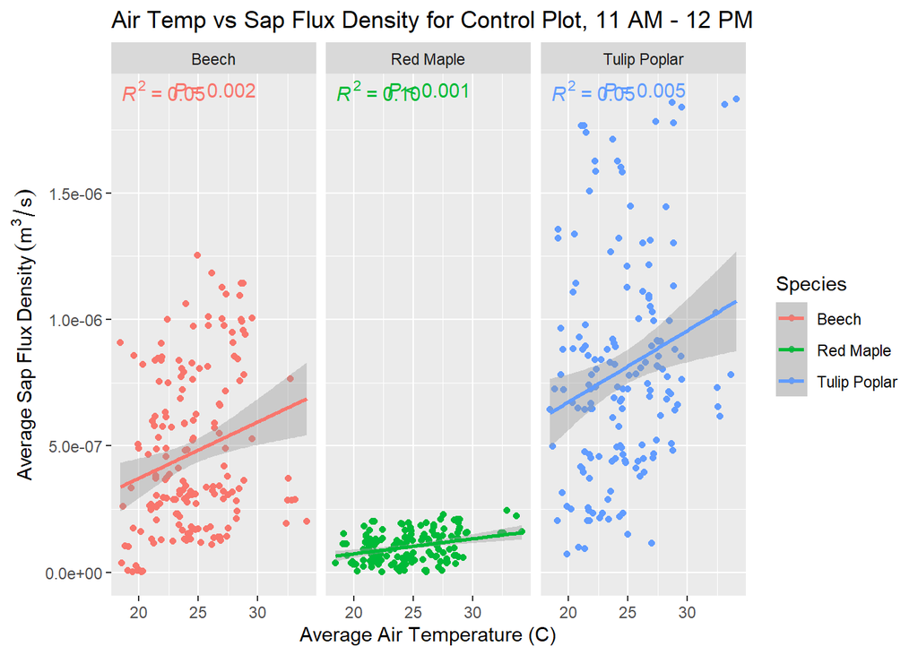

```r
full_data %>%
  mutate(Hour = hour(TIMESTAMP)) %>%
  mutate(Date = date(TIMESTAMP)) %>%
  filter(Plot == "Control") %>%
  filter(Hour >= 11, Hour <= 12) %>%
  filter(Date >= weeks_start & Date <= weeks_end) %>%
  filter(Fd <= 0.000002, Fd > 0) %>%
  group_by(Species, TIMESTAMP) %>%
  summarise(F_avg = mean(Fd, na.rm = FALSE),
            temp_avg = mean(TEMP, na.rm = FALSE)) -> temp_plot_avg
temp_plot_avg %>%
  ggplot(aes(x = temp_avg, y = F_avg,
             color = Species)) +
  geom_point() +
  geom_smooth(method = "lm") + ylim(0, NA) +
  facet_wrap(~Species, scale = "fixed") +
  #facet_wrap(~Plot, scale = "free") +
  stat_poly_eq(aes(label = paste(..rr.label.., sep = "~~~")),
               formula = y ~ x, label.x = 0.05, label.y = 0.99) +
  stat_poly_eq(aes(label = paste(..p.value.label.., sep = "~~~")),
               formula = y ~ x, label.x = 0.3, label.y = 0.985) +
  labs(x = "Average Air Temperature (C)",
       y = expression(Average~Sap~Flux~Density~(m^3/s)),
       title = "Air Temp vs Sap Flux Density for Control Plot, 11 AM - 12 PM")
```

Photosynthetically active radiation:

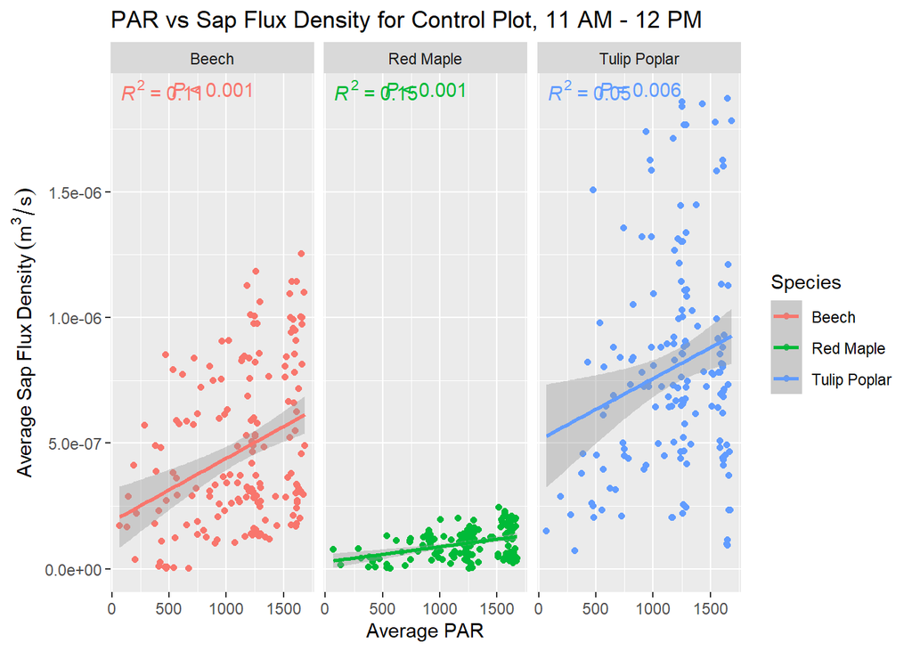

```r
full_data %>%
  mutate(Hour = hour(TIMESTAMP)) %>%
  mutate(Date = date(TIMESTAMP)) %>%
  filter(Plot == "Control") %>%
  filter(Hour >= 11, Hour <= 12) %>%
  filter(Date >= weeks_start & Date <= weeks_end) %>%
  filter(Fd <= 0.000002, Fd > 0) %>%
  group_by(Species, TIMESTAMP) %>%
  summarise(F_avg = mean(Fd, na.rm = FALSE),
            par_avg = mean(PAR, na.rm = FALSE)) -> par_plot_avg
par_plot_avg %>%
  ggplot(aes(x = par_avg, y = F_avg,
             color = Species)) +
  geom_point() +
  geom_smooth(method = "lm") + ylim(0, NA) +
  facet_wrap(~Species, scale = "fixed") +
  #facet_wrap(~Plot, scale = "free") +
  stat_poly_eq(aes(label = paste(..rr.label.., sep = "~~~")),
               formula = y ~ x, label.x = 0.05, label.y = 0.99) +
  stat_poly_eq(aes(label = paste(..p.value.label.., sep = "~~~")),
               formula = y ~ x, label.x = 0.3, label.y = 0.985) +
  labs(x = "Average PAR",
       y = expression(Average~Sap~Flux~Density~(m^3/s)),
       title = "PAR vs Sap Flux Density for Control Plot, 11 AM - 12 PM")
```

Soil volumetric water content:

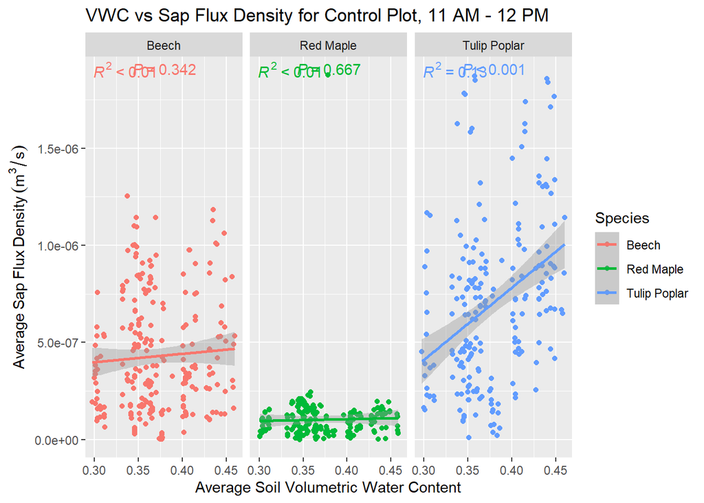

```r
full_data %>%
  mutate(Hour = hour(TIMESTAMP)) %>%
  mutate(Date = date(TIMESTAMP)) %>%
  filter(Plot == "Control") %>%
  filter(Hour >= 11, Hour <= 12) %>%
  filter(Date >= weeks_start & Date <= weeks_end) %>%
  filter(Fd <= 0.000002, Fd > 0) %>%
  group_by(Species, TIMESTAMP) %>%
  summarise(F_avg = mean(Fd, na.rm = FALSE),
            vwc_avg = mean(soil_vwc_15cm, na.rm = FALSE)) -> vwc_plot_avg
vwc_plot_avg %>%
  ggplot(aes(x = vwc_avg, y = F_avg,
             color = Species)) +
  geom_point() +
  geom_smooth(method = "lm") + ylim(0, NA) +
  facet_wrap(~Species, scale = "fixed") +
  #facet_wrap(~Plot, scale = "free") +
  stat_poly_eq(aes(label = paste(..rr.label.., sep = "~~~")),
               formula = y ~ x, label.x = 0.05, label.y = 0.99) +
  stat_poly_eq(aes(label = paste(..p.value.label.., sep = "~~~")),
               formula = y ~ x, label.x = 0.3, label.y = 0.985) +
  labs(x = "Average Soil Volumetric Water Content",
       y = expression(Average~Sap~Flux~Density~(m^3/s)),
       title = "VWC vs Sap Flux Density for Control Plot, 11 AM - 12 PM")
```

All done!